# 疯魔的时代，32万人，和他们的债务陷阱 —— 对拍拍贷借款人行为的观察

## by 过年胖十斤的大卤蛋 & 垫了三层坐垫都硌的太师椅

## 简介

### 项目背景与兴趣点

首先，这是一份作业。

其次，这个数据是拍拍贷公司提供的。拍拍贷公司自认为是国内首屈一指的互联网金融公司，其撮合了无数没有良好投资渠道的个人向囊中羞涩的人放高利贷，从中抽取高额手续费盈利。公司成立于2007年，并与2017年在纽交所上市，一时风光无限。

最后，进入正题：

此数据集发布的主要目的是为拍拍贷公司手机风控人才，因此关于这个数据集的项目主要用于风控模型的建立。发布数据集的科赛网上有大量参与拍拍贷互金训练营的同学们的作业，都非常优秀。

但是，我们对于风险控制不感兴趣。这个数据集搜集自2015-2017年。这是拍拍贷公司最后冲刺，准备上市的三两年，同时也是中国在经历18年的寒冬之前，最后的萎缩到狂欢的三年。

根据[财经数字说](http://datanews.caixin.com/2015-07-08/100826978.html)整理，14年7月开始，沉寂整整6年的A股开始爬升。尽管证监会察觉股市过快上涨，重拳打击融资融券，但A股在短暂的暴跌后重新开始上涨过程。2015年1-5月，上证指数上涨超过40%，诞生了三十余位新的亿万富翁。这个过程当中，大量新股民入市的。5月28日的大幅调整也没有阻挡股市的继续上涨。不过，正如股市名言所言，2015年6月12日，股市在达到5176点，7年以来的最高点后，进入狂跌模式。

```
“牛市在悲观中孕育，在怀疑中成长，在乐观中成熟，在狂喜中结束。”
```

6月19日，第一个千股跌停，当周A股跌幅13%；6月26日，两千股跌停，创业板当日下跌8.9%。6月27日开始，监管层开始宣布救市措施：从一开始的定向降准降息，到发文宣布缩紧IPO数量直至最终冻结IPO，到最终确定国家队入场救市，力度增幅之大，让人不敢相信这一系列动作是监管层两周之内的连续决策。但上述措施仅仅保住了少数权重股：至2015年7月8日，A股市场47.2%，共1312只股票停牌；不在国家队支持范围的股票大部分跌停；上证指数重新回到3500点左右，重新开始漫长的熊市征程。

股灾的影响显然是巨大的。2015年, 李总理发出了“互联网+”的创业号召；但是随着股市全面崩盘，许多基金和有能力投资的个人损失惨重，直接限制了初创企业的融资能力。彼时，O2O大战正如火如荼——百度宣布自己的使命是“连接服务”，并用200亿打响O2O保卫战，腾讯阿里紧随其后疯狂为美团，饿了么和口碑注资，巨头主推的烧钱打法成为O2O行业所有人的共识。而没有巨头傍身又将所谓“屌丝经济”奉为圭臬的中小O2O企业花钱如流水，却因股灾，后续融资无门，且这些企业相比巨头缺乏经营思路、人才储备和巨量的现金，只好纷纷倒闭（见[2015年O2O死亡榜](http://tech.163.com/15/1021/21/B6FV49TA000915BF.html))。与此同时，现在所谓的“新旧动能转换”根本没有准备完成，全国政策的主题思路还在“去库存”上，为2008年4万亿的大基建项目造成的过剩产能填坑。传统企业转型有待时日，制造业的制造水平和中国企业的创新能力的发展还仅仅处于萌芽阶段，新兴互联网企业还处于重运营抢地盘的阶段（从巨头对O2O行业的狂热就能看出来），无力支撑社会整体的经济增长。中国经济在股市带来的短暂狂喜后突然面对着巨大的下行压力。

如果我们将社会的投资主体分为政府，企业和居民三大类并分别分析其债务状况，那么截至2016年：地方政府债务负担沉重，2008年开启的大基建留下的债务尚未消化完成；国企资产负债率已经远远超过100%，而私营企业融资成本居高不下，债务关系复杂，且企业部门合债务占GDP 170%左右，全球最高，只有居民部门尚有增加杠杆的空间。[摆脱经济困局，只能寄希望于居民部门加杠杆](http://opinion.caixin.com/2016-03-01/100914302.html)，松绑房地产，刺激消费。

为了重新拉动经济，中央悍然祭出宽松货币政策，2015年下半年全面降准降息，增加货币供应量，而2015年人民币贷款量[增加11.72万亿](https://news.fang.com/open/29087156.html)。在房地产市场“去库存”和“货币化棚改”的助推下，在股市暴跌后资产贬值的恐慌之下，在优质投资标的稀缺的情况下，2016年房地产市场在经历两年的沉寂后重新开启[疯狂上涨](http://www.sohu.com/a/126243013_473260)行情，以应对内需不足和经济下行压力。[以深圳为例](http://wuyuefeng.blog.caixin.com/archives/197987)，2015年4月，深圳新房均价2.6万元/平，2016年3月达到近5.4万元/平，涨幅高达107.7%；二手房则是从3.4万元/平涨到了5.2万元/平，涨幅52.9%。相对应的，2016年，[中国居民部门杠杆率暴增5%](http://finance.sina.com.cn/stock/t/2017-04-06/doc-ifyeayzu6942394.shtml)， 而[收缩的企业部门杠杆率，不乐观的收入预期则实际意味着居民部门债务风险的上升](https://wallstreetcn.com/articles/255335)。

相对应的，房地产的重振也刺激了消费。当房地产上涨之势，拥有房产的居民名义财富出现大幅上涨，财富信心增强，刺激了高端消费；与此同时，因为房屋本身升值的空间就能够打平投资成本，因此房租保持稳定。而房价的过快上涨，[导致原本拥有购房资格的人被剥夺购房资格](http://zhang-ming.blog.caixin.com/archives/196028)，从而增加其他高端消费支出并开始寻求很难入场的房地产和贫弱无力的股市之外的投资渠道。2012年开始发展的P2P行业进入成熟和政策利好阶段，平台高利率吸引了大量手持资金的自然人或机构前来投资，构成P2P及消费金融泡沫的原动力。

与此同时，居民消费升级正式启动，投资方开始鼓吹“消费升级”概念；80/90后强烈的消费意愿和较低的收入水平之间的矛盾，被消费金融企业深耕消费场景进一步激发，而16-17年开启的消费升级大潮更是将居民消费借贷水平。据[艾瑞](http://report.iresearch.cn/report_pdf.aspx?id=3128)观察，2017年，互联网消费金融房贷规模增速达到了904%。疯狂的背后，过度授信，疯狂催收，资质审核不严的问题也直接为后续的P2P严监管和暴雷潮埋下了伏笔。

所以我们认为，这组数据见证的，是居民部门杠杆高企的三年，是面对下行压力和转型不利不得不饮鸩止渴的三年，也是可能是中国经济在彻底完成转型之前，比特币狂潮来临之前最后的，每个人都亲身参与的最后的疯狂。鼓吹消费，鼓吹享乐，狂风吹过之后，还是一地鸡毛。

因此，分析在这个疯魔的时段借款人的行为，勾勒他们的画像，可能比我们想得更有意义：它见证了一场集体的狂欢。我们将把数据集反过来看，从已有的脱敏信息倒推回基本的问题：他们是谁？他们为什么借钱？他们又多少负债。说是画像，其实我们永远也不会知道这些借款人叫什么，有没有大学学历，长得好不好看，但我们将通过探索已知的借款人信息，以期用数据勾勒出他们的面貌，他们的奋斗，他们的焦虑，他们的欲望，从而一瞥业已远去的疯狂背后，每个人都属于但又不属于每个人的故事。我们将着重探索包括但不限于以下主题的问题： - 什么因素可能影响借款人借入的金额？谁借的更多？谁借的比较少？ - 借款人借钱时候的债务状况如何？ - 有没有借款人过度借贷以债养债？如果有？有多少？变化趋势是怎样的？ - 不同负债水平的人，借款行为有没有差异？

### 数据集基本情况说明及变量字典

##### 基本情况

我们所分析的LC表格，是拍拍贷公司提供的标的特征表，**每支标一条记录**。根据[数据集提供方的表述](https://www.kesci.com/home/dataset/58c614aab84b2c48165a262d): 这些数据集所提供数据为拍拍贷真实业务数据，时间段为2015年1月1日至2017年1月30日，但仅占真实业务数据的10%。数据集提供方不能确定抽样方法（在此我们假设抽样是完全随机的，也即样本可以反映总体的特征）。也即： - 每一笔贷款对应一条记录； - 我们并不清楚每条标对应的主体是否为同一个人； - 从这个数据中推导得到的结果不反映拍拍贷平台的整体情况。

##### 变量字典

数据集共有21个字段，包括一个主键（listingid）、7个标的特征和13个成交当时的借款人信息，全部为成交当时可以获得的信息。具体的字段描述如下：

| 字段序号 | 字段名 | 字段注释 |
| --- | --- | --- |
| 1 | ListingId | 列表序号，为列表的唯一键。 |
| 2 | 借款金额 | 列表成交总金额。 |
| 3 | 借款期限 | 总的期数（按月计）。 |
| 4 | 借款利率 | 年化利率（百分数）。 |
| 5 | 借款成功日期 | 列表成交的日期。都在2015年1月1日以后。 |
| 6 | 初始评级 | 列表成交时的信用评级。AAA为安全标，AA为赔标，A-F为信用等级。 |
| 7 | 借款类型 | 分为’应收安全标’，‘电商’，‘APP闪电’，‘普通’和‘其他’。 |
| 8 | 是否首标 | 该标是否为借款人首标。 |
| 9 | 年龄 | 借款人在该列表借款成功时的年龄。 |
| 10 | 性别 | 该列表借款人性别。 |
| 11 | 手机认证 | 该列表借款人手机实名认证是否成功。 |
| 12 | 户口认证 | 该列表借款人户口认证是否成功。 |
| 13 | 视频认证 | 该列表借款人视频认证是否成功。 |
| 14 | 学历认证 | 该列表借款人学历认证是否成功。成功则表示有大专及以上学历。 |
| 15 | 征信认证 | 该列表借款人征信认证是否成功。成功则表示有人行征信报告。 |
| 16 | 淘宝认证 | 该列表借款人淘宝认证是否成功。成功则表示为淘宝店主。 |
| 17 | 历史成功借款次数 | 借款人在该列表成交之前的借款成功次数。 |
| 18 | 历史成功借款金额 | 借款人在该列表成交之前的借款成功金额。 |
| 19 | 总待还本金 | 借款人在该列表成交之前待还本金金额。 |
| 20 | 历史正常还款期数 | 借款人在该列表成交之前的按期还款期数。 |
| 21 | 历史逾期还款期数 | 借款人在该列表成交之前的逾期还款期数。 |

### 数据集结构初探

```
## Classes 'spec_tbl_df', 'tbl_df', 'tbl' and 'data.frame': 328553 obs. of  21 variables:
##  $ ListingId       : num  126541 133291 142421 149711 152141 ...
##  $ 借款金额        : num  18000 9453 27000 25000 20000 ...
##  $ 借款期限        : num  12 12 24 12 6 12 6 12 12 6 ...
##  $ 借款利率        : num  18 20 20 18 16 14 18 18 16 18 ...
##  $ 借款成功日期    : Date, format: "2015-05-04" "2015-03-16" ...
##  $ 初始评级        : chr  "C" "D" "E" "C" ...
##  $ 借款类型        : chr  "其他" "其他" "普通" "其他" ...
##  $ 是否首标        : chr  "否" "否" "否" "否" ...
##  $ 年龄            : num  35 34 41 34 24 36 27 32 33 25 ...
##  $ 性别            : chr  "男" "男" "男" "男" ...
##  $ 手机认证        : chr  "成功认证" "未成功认证" "成功认证" "成功认证" ...
##  $ 户口认证        : chr  "未成功认证" "成功认证" "未成功认证" "成功认证" ...
##  $ 视频认证        : chr  "成功认证" "未成功认证" "未成功认证" "成功认证" ...
##  $ 学历认证        : chr  "未成功认证" "未成功认证" "未成功认证" "未成功认证" ...
##  $ 征信认证        : chr  "未成功认证" "未成功认证" "未成功认证" "未成功认证" ...
##  $ 淘宝认证        : chr  "未成功认证" "未成功认证" "未成功认证" "未成功认证" ...
##  $ 历史成功借款次数: num  11 4 5 6 13 7 15 7 7 9 ...
##  $ 历史成功借款金额: num  40326 14500 21894 36190 77945 ...
##  $ 总待还本金      : num  8713 7891 11726 9703 0 ...
##  $ 历史正常还款期数: num  57 13 25 41 118 56 75 52 41 49 ...
##  $ 历史逾期还款期数: num  16 1 3 1 14 0 8 0 2 4 ...
##  - attr(*, "spec")=
##   .. cols(
##   ..   ListingId = col_double(),
##   ..   借款金额 = col_double(),
##   ..   借款期限 = col_double(),
##   ..   借款利率 = col_double(),
##   ..   借款成功日期 = col_date(format = ""),
##   ..   初始评级 = col_character(),
##   ..   借款类型 = col_character(),
##   ..   是否首标 = col_character(),
##   ..   年龄 = col_double(),
##   ..   性别 = col_character(),
##   ..   手机认证 = col_character(),
##   ..   户口认证 = col_character(),
##   ..   视频认证 = col_character(),
##   ..   学历认证 = col_character(),
##   ..   征信认证 = col_character(),
##   ..   淘宝认证 = col_character(),
##   ..   历史成功借款次数 = col_double(),
##   ..   历史成功借款金额 = col_double(),
##   ..   总待还本金 = col_double(),
##   ..   历史正常还款期数 = col_double(),
##   ..   历史逾期还款期数 = col_double()
##   .. )
```

### 对数据集的调整与清洁

总的来说，我们的数据集十分干净，但依旧有一些不尽如人意的地方。我们进行以下调整，以更好的进行后续的数据分析。

##### 判断类型变量的文本转化为数值

观察数据集可知，手机、户口、学历、征信、视频、淘宝等认证信息为文字的“成功认证”或“未成功认证”，`是否首标`列也为文字的`是`或`否`。我们将这些列中表明“是”的标定为数字1，表明“否”的标定为数字0，以方便后续的计算和观察。

##### 将有顺序的列排序

观察数据集可知，部分列为分类变量，但被自动处理为字符串。我们对这些列进行一些调整，使其变为分类变量，并为部分列加上顺序。

```r
ppd_lc$'借款期限' <- factor(ppd_lc$'借款期限', ordered = TRUE, levels = c(1:24))
ppd_lc$'初始评级' <- factor(ppd_lc$'初始评级', ordered = TRUE,
                        levels = c('AAA', 'AA', 'A', 'B', 'C', 'D', 'E', 'F'))
ppd_lc$'借款类型' <- factor(ppd_lc$'借款类型')
ppd_lc$'性别' <- factor(ppd_lc$'性别')
```

##### 创建新的变量：总认证数 & 逾期率

观察数据集内容可知： - 各认证数可以累计； - 可以计算历史单笔借款均值，以衡量借款人每一次借入的资金数额；平均数值与当前借款行为的对比可能能提供洞见 - 可以通过历史还款记录计算借款人的逾期率；逾期率不能叫逾期率，会报错；以观察借款人的守信程度 - 可以计算旧借款的偿还率；偿还率也不能叫偿还率，会报错；以观察借款人债务水平的变化 - 可以将偿还率分类：有人从来没借过钱，有人借了钱还没还就又借了钱，有人还了一部分又来借钱，有人还完了又来借钱；以观察借款人债务水平的变化 - 可以计算旧借款在借入款项后所占的比例，以观察借款人债务水平的变化；

```r
# Calculating Total of Verifications 计算总认证数
ppd_lc$'总认证数' <- ppd_lc$'手机认证' + ppd_lc$'户口认证' + ppd_lc$'学历认证' +
                     ppd_lc$'征信认证' + ppd_lc$'视频认证' + ppd_lc$'淘宝认证'
ppd_lc$'总认证数' <- as.numeric(ppd_lc$'总认证数')

# 计算历史平均借款金额
ppd_lc$'历史单笔借款均值' <- (ppd_lc$'历史成功借款金额' /
                        ppd_lc$'历史成功借款次数')
ppd_lc$'历史单笔借款均值'[is.na(ppd_lc$'历史单笔借款均值')] <- 0


# Calculating Overdue Rate 计算逾期率
ppd_lc$'逾期率' <- ppd_lc$'历史逾期还款期数' / (ppd_lc$'历史正常还款期数' + ppd_lc$'历史逾期还款期数') * 100
ppd_lc$'逾期率'[is.nan(ppd_lc$'逾期率')] <- 0
ppd_lc$'逾期率' <- as.numeric(ppd_lc$'逾期率')
ppd_lc$'OverdueRate' <- ppd_lc$'逾期率'

# Calculating Pay-off Rate 计算偿还率
ppd_lc$'PayoffRate' <- ((ppd_lc$'历史成功借款金额' - ppd_lc$'总待还本金') / ppd_lc$'历史成功借款金额') * 100
ppd_lc$'PayoffRate'[is.na(ppd_lc$'PayoffRate')] <- -1

# Categorizing Pay-off Rates 构建还款进度分类
ppd_lc$'PayoffCate' <- cut(ppd_lc$'PayoffRate',
                           breaks = c(-2, -1, 0, 99, 100),
                           labels = c("从未借款", "未开始归还", "部分还清", "全部还清"),
                           right = TRUE)
ppd_lc$'PayoffCate' <- factor(ppd_lc$'PayoffCate',
                              ordered = TRUE,
                              levels = c("从未借款", "未开始归还", "部分还清", "全部还清"))

# Categorizing Whether has Unpaid loans when applying 借款时是否有未偿清负债
ppd_lc$Unpaid_Total <- ppd_lc$'总待还本金'
ppd_lc$UnpaidCate <- NA
ppd_lc$UnpaidCate <- ifelse(ppd_lc$Unpaid_Total == 0, "无欠款", "有欠款")
ppd_lc$'UnpaidCate' <- factor(ppd_lc$'UnpaidCate', ordered = TRUE)

# Calculating Old Loan Percentage 计算待还款项占总待还金额比例
ppd_lc$'OldLoanPCT' <- (ppd_lc$'总待还本金' /
                          (ppd_lc$'借款金额' + ppd_lc$'总待还本金')) * 100
```

##### 将转化为数值类型的认证数据转化为分类

```r
ppd_lc$'手机认证' <- factor(ppd_lc$'手机认证')
ppd_lc$'户口认证' <- factor(ppd_lc$'户口认证')
ppd_lc$'学历认证' <- factor(ppd_lc$'学历认证')
ppd_lc$'征信认证' <- factor(ppd_lc$'征信认证')
ppd_lc$'视频认证' <- factor(ppd_lc$'视频认证')
ppd_lc$'淘宝认证' <- factor(ppd_lc$'淘宝认证')
ppd_lc$'是否首标' <- factor(ppd_lc$'是否首标')
```

##### 将数据集拆分为新用户和老用户两个数据集

我们将只对老用户进行分析，因为老用户留下的记录更多

```r
ppd_lc_old <- subset(ppd_lc, ppd_lc$"是否首标" == 0)
ppd_lc_new <- subset(ppd_lc, ppd_lc$"是否首标" == 1)
```

### 在已经探究的特性中，是否存在任何异常分布？

##### 空值检验

```
##  /\     /\
## {  `---'  }
## {  O   O  }
## ==>  V <==  No need for mice. This data set is completely observed.
##  \  \|/  /
##   `-----'
```

[figure not shown]

```
##        ListingId 借款金额 借款期限 借款利率 借款成功日期 初始评级 借款类型
## 328553         1        1        1        1            1        1        1
##                0        0        0        0            0        0        0
##        是否首标 年龄 性别 手机认证 户口认证 视频认证 学历认证 征信认证
## 328553        1    1    1        1        1        1        1        1
##               0    0    0        0        0        0        0        0
##        淘宝认证 历史成功借款次数 历史成功借款金额 总待还本金
## 328553        1                1                1          1
##               0                0                0          0
##        历史正常还款期数 历史逾期还款期数 总认证数 历史单笔借款均值 逾期率
## 328553                1                1        1                1      1
##                       0                0        0                0      0
##        OverdueRate PayoffRate PayoffCate Unpaid_Total UnpaidCate
## 328553           1          1          1            1          1
##                  0          0          0            0          0
##        OldLoanPCT
## 328553          1 0
##                 0 0
```

##### 列值基本描述检验

```
##    ListingId           借款金额         借款期限         借款利率
##  Min.   :  126541   Min.   :   100   12     :215330   Min.   : 6.5
##  1st Qu.:11908871   1st Qu.:  2033   6      : 84486   1st Qu.:20.0
##  Median :19523251   Median :  3397   9      : 10769   Median :20.0
##  Mean   :19079479   Mean   :  4424   10     :  5472   Mean   :20.6
##  3rd Qu.:26298621   3rd Qu.:  5230   11     :  5351   3rd Qu.:22.0
##  Max.   :32819531   Max.   :500000   3      :  1993   Max.   :24.0
##                                      (Other):  5152
##   借款成功日期           初始评级         借款类型      是否首标
##  Min.   :2015-01-01   D      :134860   APP闪电:112079   0:241090
##  1st Qu.:2016-05-08   C      :131705   电商   :  1069   1: 87463
##  Median :2016-09-11   B      : 33188   普通   :118103
##  Mean   :2016-08-05   E      : 17027   其他   : 97302
##  3rd Qu.:2016-12-01   A      : 10284
##  Max.   :2017-01-30   F      :  1489
##                       (Other):     0
##       年龄       性别        手机认证   户口认证   视频认证   学历认证
##  Min.   :17.00   男:221946   0:205546   0:318448   0:310052   0:214429
##  1st Qu.:24.00   女:106607   1:123007   1: 10105   1: 18501   1:114124
##  Median :28.00
##  Mean   :29.14
##  3rd Qu.:33.00
##  Max.   :56.00
##
##  征信认证   淘宝认证   历史成功借款次数  历史成功借款金额
##  0:318947   0:327401   Min.   :  0.000   Min.   :      0
##  1:  9606   1:  1152   1st Qu.:  0.000   1st Qu.:      0
##                        Median :  2.000   Median :   5000
##                        Mean   :  2.323   Mean   :   8786
##                        3rd Qu.:  3.000   3rd Qu.:  10355
##                        Max.   :649.000   Max.   :7405926
##
##    总待还本金      历史正常还款期数   历史逾期还款期数     总认证数
##  Min.   :      0   Min.   :   0.000   Min.   : 0.0000   Min.   :0.0000
##  1st Qu.:      0   1st Qu.:   0.000   1st Qu.: 0.0000   1st Qu.:0.0000
##  Median :   2542   Median :   5.000   Median : 0.0000   Median :1.0000
##  Mean   :   3722   Mean   :   9.948   Mean   : 0.4233   Mean   :0.8416
##  3rd Qu.:   5447   3rd Qu.:  13.000   3rd Qu.: 0.0000   3rd Qu.:1.0000
##  Max.   :1172653   Max.   :2507.000   Max.   :60.0000   Max.   :6.0000
##
##  历史单笔借款均值     逾期率        OverdueRate       PayoffRate
##  Min.   :     0   Min.   :  0.00   Min.   :  0.00   Min.   : -1.00
##  1st Qu.:     0   1st Qu.:  0.00   1st Qu.:  0.00   1st Qu.: -1.00
##  Median :  2500   Median :  0.00   Median :  0.00   Median : 34.54
##  Mean   :  2812   Mean   :  2.85   Mean   :  2.85   Mean   : 35.13
##  3rd Qu.:  4000   3rd Qu.:  0.00   3rd Qu.:  0.00   3rd Qu.: 55.67
##  Max.   :500000   Max.   :100.00   Max.   :100.00   Max.   :100.00
##
##       PayoffCate      Unpaid_Total      UnpaidCate       OldLoanPCT
##  从未借款  : 87463   Min.   :      0   无欠款:101301   Min.   : 0.00
##  未开始归还:  1488   1st Qu.:      0   有欠款:227252   1st Qu.: 0.00
##  部分还清  :225755   Median :   2542                   Median :43.85
##  全部还清  : 13847   Mean   :   3722                   Mean   :39.85
##                      3rd Qu.:   5447                   3rd Qu.:68.87
##                      Max.   :1172653                   Max.   :99.75
##
```

我们看到，历史成功借款次数有非常夸张的649次，借款金额有非常夸张的50万，历史成功借款金额有夸张的740万，总待还本金有一个人有117万之巨，历史成功借款金额也有74万。逾期率也有100%的。这些极值需要我们调查一下。

##### 最大借款金额

```
## # A tibble: 56 x 30
##    ListingId 借款金额 借款期限 借款利率 借款成功日期 初始评级 借款类型
##        <dbl>    <dbl> <ord>       <dbl> <date>       <ord>    <fct>
##  1   3097341   500000 1             6.5 2015-07-06   A        其他
##  2   3220201   500000 1            10   2015-07-15   A        其他
##  3   3250931   500000 1            10   2015-07-17   A        其他
##  4   3616281   500000 3            10   2015-08-12   A        其他
##  5   3628471   500000 3            10   2015-08-12   A        其他
##  6   3659691   500000 2            10   2015-08-14   A        其他
##  7   3840301   500000 1            10   2015-08-25   A        其他
##  8   3981541   500000 1             9   2015-09-02   A        其他
##  9   4429331   500000 6            14   2015-09-25   B        电商
## 10   4434731   500000 6            14   2015-09-28   B        电商
## # ... with 46 more rows, and 23 more variables: 是否首标 <fct>,
## #   年龄 <dbl>, 性别 <fct>, 手机认证 <fct>, 户口认证 <fct>,
## #   视频认证 <fct>, 学历认证 <fct>, 征信认证 <fct>, 淘宝认证 <fct>,
## #   历史成功借款次数 <dbl>, 历史成功借款金额 <dbl>, 总待还本金 <dbl>,
## #   历史正常还款期数 <dbl>, 历史逾期还款期数 <dbl>, 总认证数 <dbl>,
## #   历史单笔借款均值 <dbl>, 逾期率 <dbl>, OverdueRate <dbl>,
## #   PayoffRate <dbl>, PayoffCate <ord>, Unpaid_Total <dbl>,
## #   UnpaidCate <ord>, OldLoanPCT <dbl>
```

##### 最大借款金额-摘要

```
##    ListingId           借款金额        借款期限     借款利率
##  Min.   : 3097341   Min.   :5e+05   6      :35   Min.   : 6.50
##  1st Qu.: 5116334   1st Qu.:5e+05   1      :10   1st Qu.:13.00
##  Median : 9799516   Median :5e+05   3      : 9   Median :14.00
##  Mean   :10710709   Mean   :5e+05   2      : 1   Mean   :13.01
##  3rd Qu.:15932198   3rd Qu.:5e+05   12     : 1   3rd Qu.:14.00
##  Max.   :21788801   Max.   :5e+05   4      : 0   Max.   :16.00
##                                     (Other): 0
##   借款成功日期           初始评级     借款类型  是否首标      年龄
##  Min.   :2015-07-06   B      :43   APP闪电: 0   0:41     Min.   :25.00
##  1st Qu.:2015-10-27   A      :13   电商   :43   1:15     1st Qu.:31.00
##  Median :2016-03-19   AAA    : 0   普通   : 0            Median :36.00
##  Mean   :2016-03-06   AA     : 0   其他   :13            Mean   :36.43
##  3rd Qu.:2016-07-20   C      : 0                         3rd Qu.:39.25
##  Max.   :2016-10-19   D      : 0                         Max.   :56.00
##                       (Other): 0
##  性别    手机认证 户口认证 视频认证 学历认证 征信认证 淘宝认证
##  男:38   0:14     0:38     0:16     0:41     0:47     0:29
##  女:18   1:42     1:18     1:40     1:15     1: 9     1:27
##
##
##
##
##
##  历史成功借款次数 历史成功借款金额    总待还本金     历史正常还款期数
##  Min.   :0.000    Min.   :      0   Min.   :     0   Min.   : 0.000
##  1st Qu.:0.000    1st Qu.:      0   1st Qu.:     0   1st Qu.: 0.000
##  Median :1.000    Median : 500000   Median :     0   Median : 2.500
##  Mean   :1.804    Mean   : 624780   Mean   :113512   Mean   : 6.607
##  3rd Qu.:3.000    3rd Qu.:1000000   3rd Qu.:180831   3rd Qu.:10.000
##  Max.   :7.000    Max.   :2146000   Max.   :610061   Max.   :33.000
##
##  历史逾期还款期数    总认证数     历史单笔借款均值     逾期率
##  Min.   :0.0000   Min.   :0.000   Min.   :     0   Min.   : 0.000
##  1st Qu.:0.0000   1st Qu.:1.750   1st Qu.:     0   1st Qu.: 0.000
##  Median :0.0000   Median :3.000   Median :320300   Median : 0.000
##  Mean   :0.1607   Mean   :2.696   Mean   :277619   Mean   : 1.185
##  3rd Qu.:0.0000   3rd Qu.:4.000   3rd Qu.:455125   3rd Qu.: 0.000
##  Max.   :3.0000   Max.   :5.000   Max.   :500000   Max.   :16.667
##
##   OverdueRate       PayoffRate          PayoffCate  Unpaid_Total
##  Min.   : 0.000   Min.   : -1.00   从未借款  :15   Min.   :     0
##  1st Qu.: 0.000   1st Qu.: -1.00   未开始归还: 2   1st Qu.:     0
##  Median : 0.000   Median : 70.66   部分还清  :21   Median :     0
##  Mean   : 1.185   Mean   : 57.61   全部还清  :18   Mean   :113512
##  3rd Qu.: 0.000   3rd Qu.:100.00                   3rd Qu.:180831
##  Max.   :16.667   Max.   :100.00                   Max.   :610061
##
##   UnpaidCate   OldLoanPCT
##  无欠款:33   Min.   : 0.00
##  有欠款:23   1st Qu.: 0.00
##              Median : 0.00
##              Mean   :13.59
##              3rd Qu.:26.56
##              Max.   :54.96
##
```

看来，2015年7月6日- 2016年10月19日之间，共有56人选择了最高金额50万的贷款；这批贷款的还款期限普遍很短，只有1人的还款期限在12个月，而35人在6个月之内就必须还清，更有10个人1个月之内就必须还清。产品类型主要为“电商”和“其他”。

##### 最多总待还本金

```
## # A tibble: 1 x 30
##   ListingId 借款金额 借款期限 借款利率 借款成功日期 初始评级 借款类型
##       <dbl>    <dbl> <ord>       <dbl> <date>       <ord>    <fct>
## 1  23566851   160000 6              13 2016-10-31   B        电商
## # ... with 23 more variables: 是否首标 <fct>, 年龄 <dbl>, 性别 <fct>,
## #   手机认证 <fct>, 户口认证 <fct>, 视频认证 <fct>, 学历认证 <fct>,
## #   征信认证 <fct>, 淘宝认证 <fct>, 历史成功借款次数 <dbl>,
## #   历史成功借款金额 <dbl>, 总待还本金 <dbl>, 历史正常还款期数 <dbl>,
## #   历史逾期还款期数 <dbl>, 总认证数 <dbl>, 历史单笔借款均值 <dbl>,
## #   逾期率 <dbl>, OverdueRate <dbl>, PayoffRate <dbl>, PayoffCate <ord>,
## #   Unpaid_Total <dbl>, UnpaidCate <ord>, OldLoanPCT <dbl>
```

此人历史成功借款282万6千元，尚有117万2653元本金待还。她在尚有借款未还清的情况下又借入了巨额资金。借款类型为电商。可能是个淘宝店主？

##### 最多历史成功借款金额 & 最多历史借款次数

```
## # A tibble: 1 x 30
##   ListingId 借款金额 借款期限 借款利率 借款成功日期 初始评级 借款类型
##       <dbl>    <dbl> <ord>       <dbl> <date>       <ord>    <fct>
## 1   2402951    12032 6              16 2015-05-12   B        普通
## # ... with 23 more variables: 是否首标 <fct>, 年龄 <dbl>, 性别 <fct>,
## #   手机认证 <fct>, 户口认证 <fct>, 视频认证 <fct>, 学历认证 <fct>,
## #   征信认证 <fct>, 淘宝认证 <fct>, 历史成功借款次数 <dbl>,
## #   历史成功借款金额 <dbl>, 总待还本金 <dbl>, 历史正常还款期数 <dbl>,
## #   历史逾期还款期数 <dbl>, 总认证数 <dbl>, 历史单笔借款均值 <dbl>,
## #   逾期率 <dbl>, OverdueRate <dbl>, PayoffRate <dbl>, PayoffCate <ord>,
## #   Unpaid_Total <dbl>, UnpaidCate <ord>, OldLoanPCT <dbl>
```

此人历史成功借款740万5926元，分2507次归还，且全部还清了！太厉害了！这是假的吗？不太会吧，假的也不至于拿一个账号刷。难道是炒房？洗钱？只有这俩能够负担得起这么频繁的交易了吧。

## 单变量探索

### 借款相关变量

#### 借款数量-按月分布

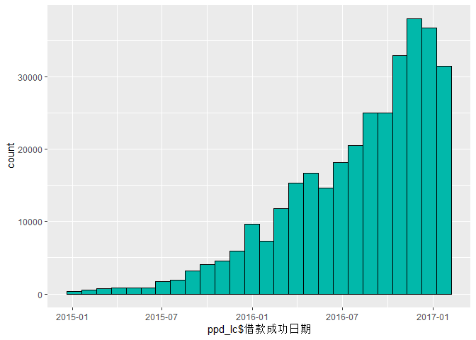

借款单量随着时间的推移，平台的扩张而不断上涨，并在16年11月达到高峰。单量在随后的两个月内有所下降。

##### 借款金额分布

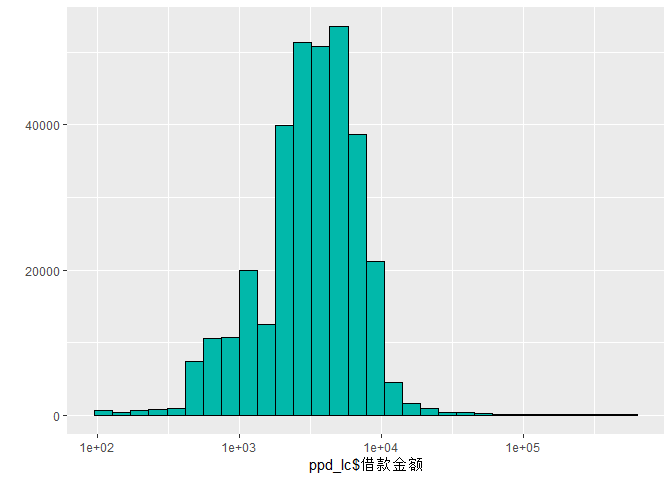

借款金额主要集中在3000元左右，借款1万元以上的用户数量明显减少。

##### 借款期限

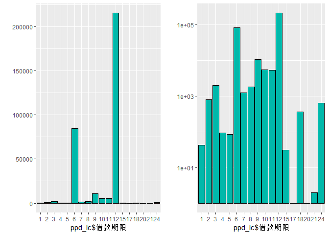

- 直接绘制图形，可以看到6个月期限和12个月期限的借款数量与其他的数量存在数量级上的差异。为了更好的展现其他借款期限的单量，我们将借款数量取10的对数进行展示。
- 观察图形不难发现：
  - 借款期限主要集中在6-12各月之间；
  - 平台的借款期限比较灵活：不仅有1，3，6，9，12等整数月（似乎这个整数迷思与季度数有关？），也存在部分2，5，8各月的借款期限。

##### 借款利率

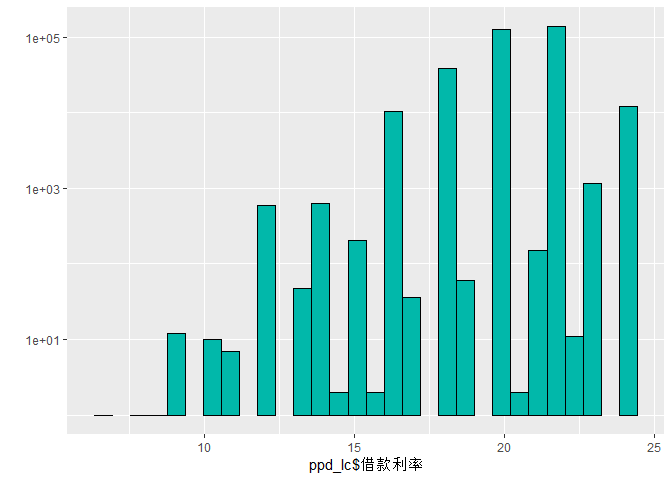

观察发现： - 我们不能确定这里的利率是指年化利率还是其他，我们假设其为年化利率 - 平台的利率非常惊人，妥妥的高利贷平台，毫无疑问： - 国家规定的最高利率不能超过10%（况且往往资金有那么高的效率），而我们看到，平台中利率低于10%的借款数量不过十几单。 - 最多的利率是20%和22%。

##### 借款类型

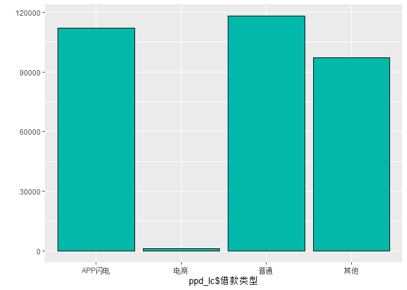

##### 逾期率分布(去除首标)

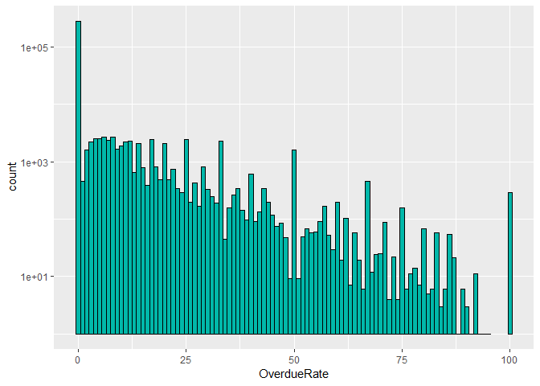

去除首标的逾期率数据是长尾数据，因此我们对计数取10的对数以便更好的观察。观察发现： - 绝大部分人还是信守承诺，或身为老用户从未借款的。这部分人有十几万； - 逾期率在30%以下，及50%都是接近千人规模； - 总体趋势上，除了100%逾期的神人之外，总体上逾期率越高人数越少。

##### 借款人借款时有无欠款的分类分布

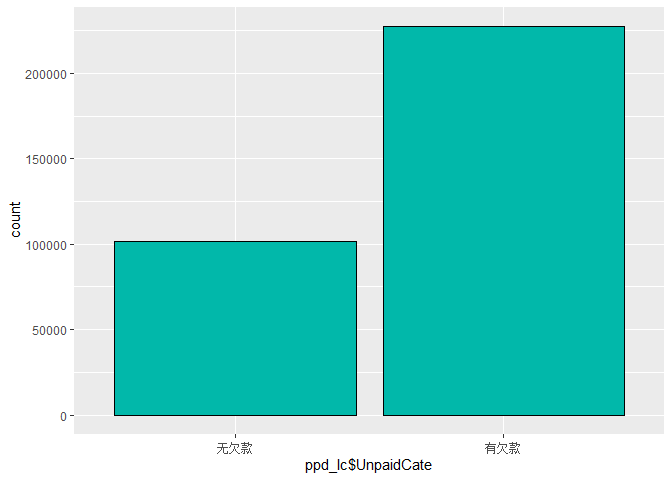

```r
ggplot(aes(x = ppd_lc$UnpaidCate), data = ppd_lc) +
  geom_histogram(color = I('black'), fill = I('#01B8AA'), stat = "count")
```

观察可知： - 只有大约10万借款人在借款时无欠款； - 大约22万借款人在借入新款项时有欠款。

##### 借款人借款时的旧债偿还情况（数值&分类计数分布）

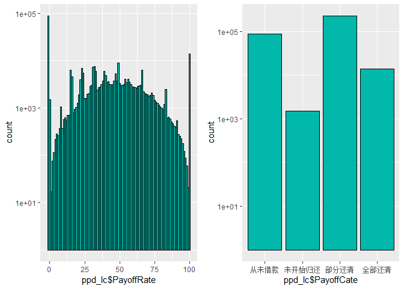

进一步探索借款时有欠款的人的偿还状况。观察发现： - 大约有10万人在此次借款之前从未借款； - 在所有之前借过款的人中，大约只有1万人左右成功的在借入新款之前还清了之前的欠款； - 有大约一千多人在借款后还未开始归还，就申请了新的借款； - 剩下的人在还未还清之前借款的前提下，申请了新的借款。

##### 原负债金额占总待还债务（包括新借入金额）比例

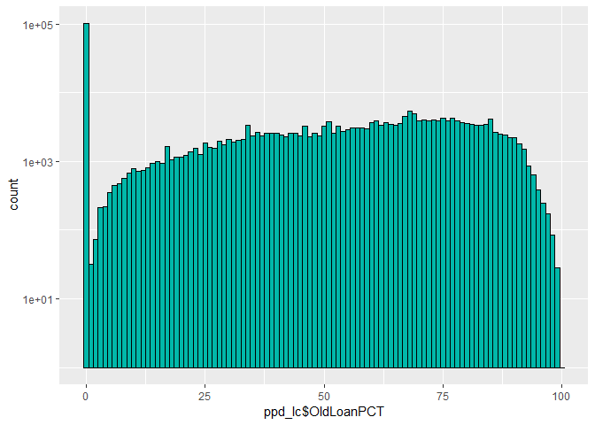

这张图将按照其旧债务占新旧整体债务的比例，由低到高排列，统计所有未还清旧贷款借款人的数量。这里用到的变量，计算的是原有债务占加上此笔借款的总债务的比例。这一比例能够很好的反映借款人的债务扩张的状态。这一比例越低，意味着借款人的债务扩张幅度越大；反之，则意味着借款人的债务扩张幅度较小。与此同时，如果借款人借新还旧以债养债，考虑到平台的利率只要集中在20%左右，那么旧债比例占到80%左右的借款人可能已经陷入债务泥沼（当然，这一观察需要更多的数据来作证）。

### 借款人相关

#### 各评级人数

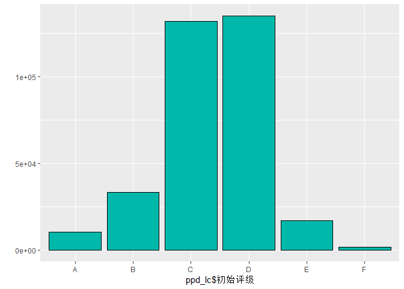

各评级人数大致符合正态分布。

#### 年龄

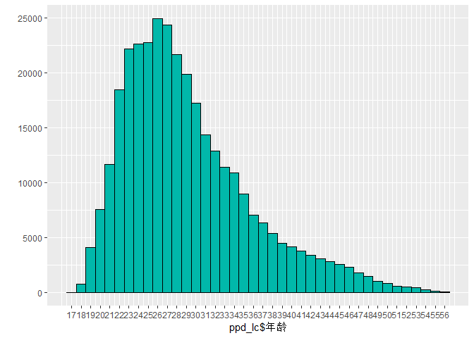

观察发现： - 拍拍贷的主力用户年龄在26-27岁，其后缓慢下降；这一年龄段的年轻人也确实处于求偶高峰期，同时购买力还没有形成； - 22岁用户较21岁用户有明显增加：这很可能是因为大学生毕业参加工作造成的，而拍拍贷的业务规则（至少是在本文撰写的时候）明确了不给学生发放贷款。

#### 历史成功借款次数

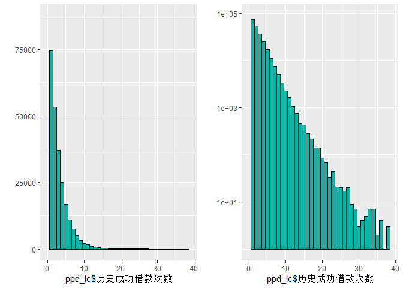

拥有更多成功借款次数的人不断减少。

#### 历史成功借款金额

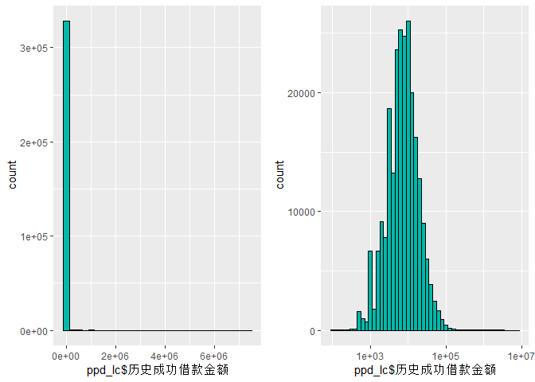

观察图形可知： - 大部分人的历史借款金额都在1万元左右； - 历史借款金额的主体部分再1000-10万之间

#### 历史单笔借款均值

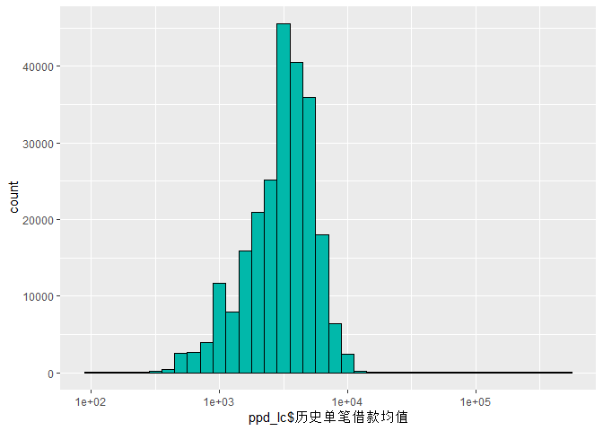

观察图形可知： - 单笔借入3000， 4000， 5000最为常见； - 单笔借入额度较小和较大的似乎都不怎么常见： - 单笔借款3000元以下的借款数量，不到3000元借款数量的一半； - 单笔5000元以上的借款数量，不到5000元借款数量的一半；

#### 总待还金额分布

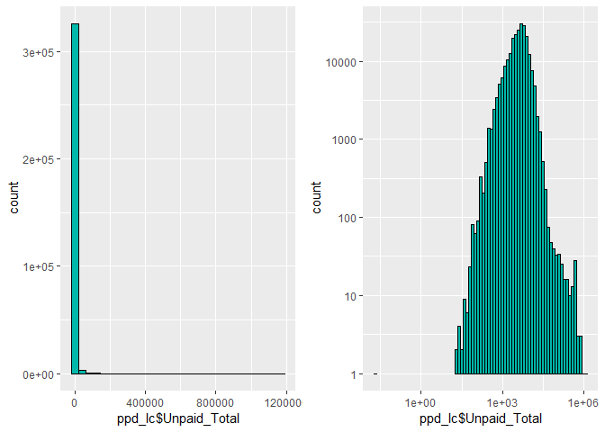

总待还本金的高峰集中在5000和6000之中，随后随着欠款的增多迅速下降。

#### 总认证数分布

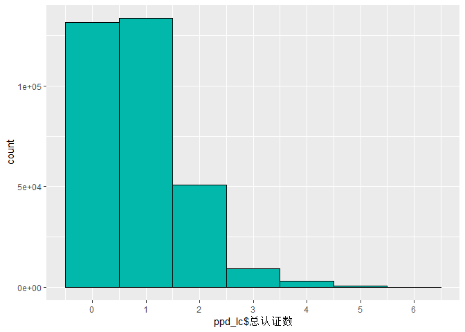

#### 各项认证分布

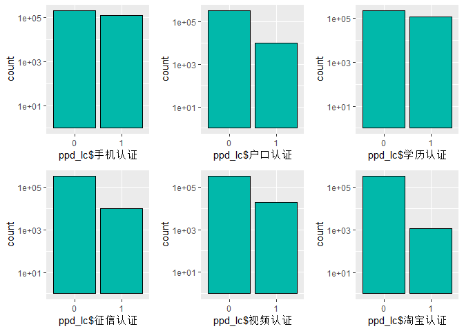

观察可知： - 手机认证和学历认证完成的比例较高，基本持平； - 淘宝认证完成的人数量少；这可能是因为这项认证仅针对淘宝店主。

## 双变量探索

### 部分变量关系总览

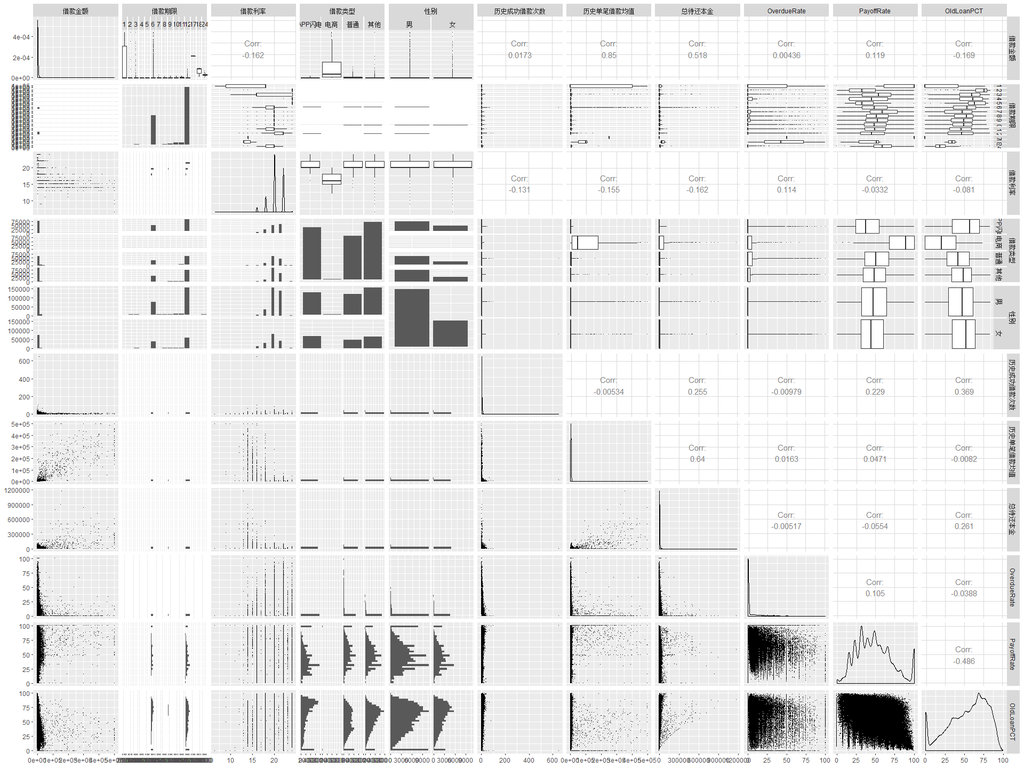

- 观察发现，
  - 借款金额与历史单笔借款均值有强相关关系；
  - 借款金额与总待还本金有较强的相关关系；
  - 出乎意料的是，借款金额与借款人历史成功借款次数关系不大；
  - 借款人借款时的还款状况与借款金额有微弱的联系
  - 电商类产品借款利率较低，还款率较高，旧债占比较低，值得进一步探索；
  - 历史单笔借款均值和总待还本金之间存在较强的线性关系。 我们将进一步探索上述发现。

### 借款金额，信用记录及借款期限的基本情况

#### 借款历史与借款金额特征：历史单笔借款均值越高，借款金额越高

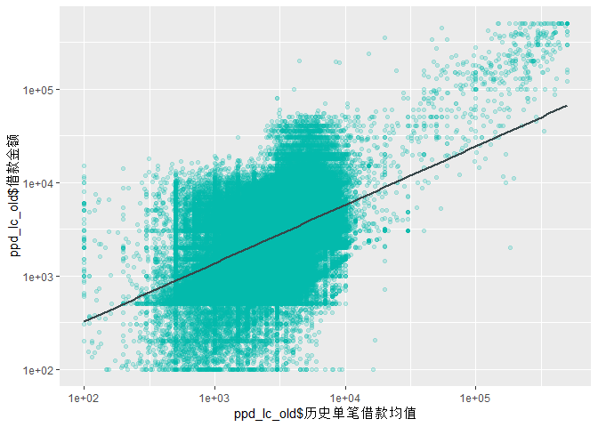

为二者关系拟合线性回归模型，结果如下：

```
##
## Call:
## lm(formula = ppd_lc_old$借款金额 ~ ppd_lc_old$历史单笔借款均值)
##
## Residuals:
##     Min      1Q  Median      3Q     Max
## -348626   -1557    -477     925  400116
##
## Coefficients:
##                              Estimate Std. Error t value Pr(>|t|)
## (Intercept)                 3.764e+02  1.275e+01   29.51   <2e-16 ***
## ppd_lc_old$历史单笔借款均值 9.365e-01  1.183e-03  791.51   <2e-16 ***
## ---
## Signif. codes:  0 '***' 0.001 '**' 0.01 '*' 0.05 '.' 0.1 ' ' 1
##
## Residual standard error: 5853 on 241088 degrees of freedom
## Multiple R-squared:  0.7221, Adjusted R-squared:  0.7221
## F-statistic: 6.265e+05 on 1 and 241088 DF,  p-value: < 2.2e-16
```

#### 借款历史与借款金额特征：(在借新还旧的人中)总待偿还本金越高，借款金额越高

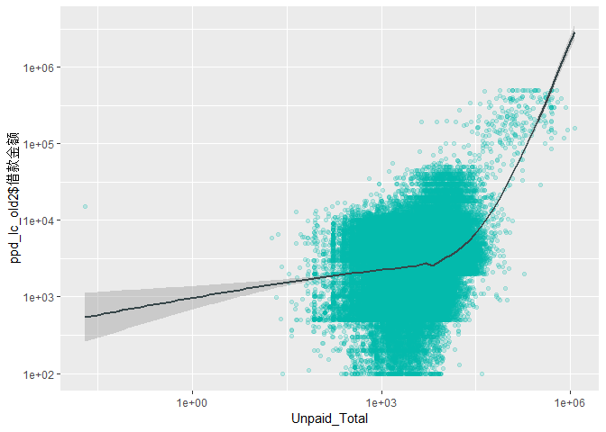

#### 借款期限 vs. 借款金额: 巨额借款期限或长或短

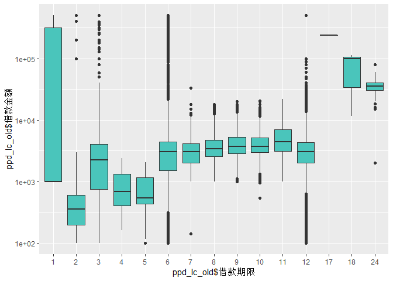

期限较短的借款反而额度较高，疑似资金过桥；借款数额在1000 - 10000之间的金额款期限反而在2-12个月；借款期限为18-24个月的，似乎是针对个人的高额度贷款。

#### 历史欠债用户借款金额异同

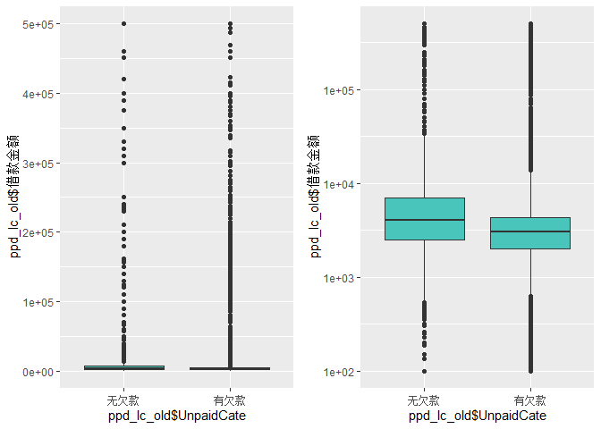

对所有非首标用户而言，借款时有无欠款对其借款均值影响不大不大

#### 历史单笔借款均值 vs. 总待还本金：总待还本金越高，历史单笔借款均值越高

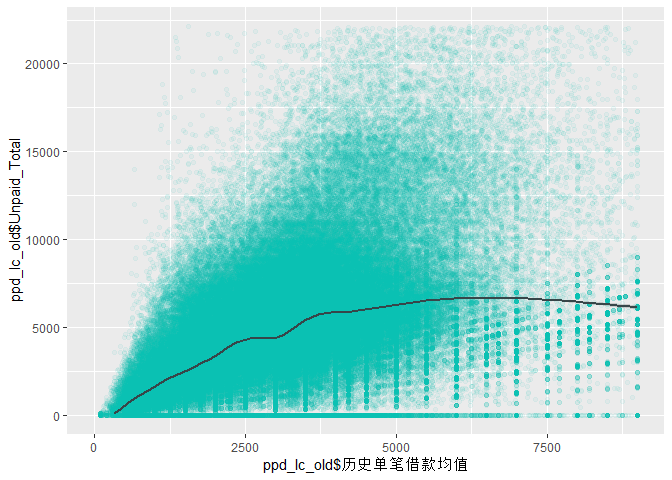

#### 还清比 vs. 旧债占比：旧债的占比越高，旧债偿清的比例越低

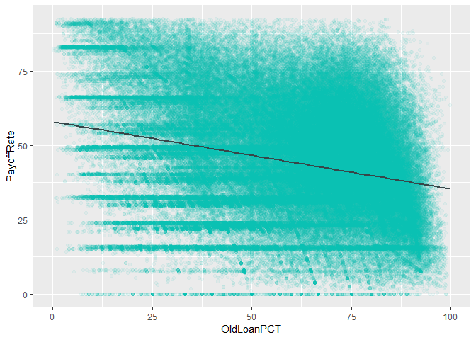

### 初始评级与其他变量之间的关系

#### 初始评级 vs. 年龄：没有显著差异

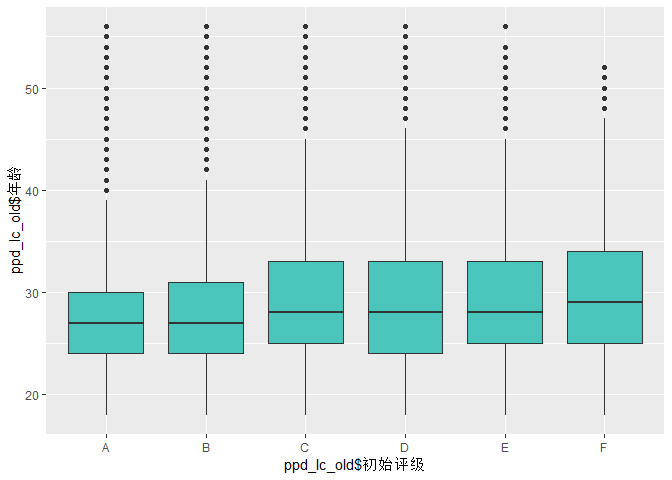

#### 初始评级 vs. 总认证数：评级越高往往认证数越多，但也有少数例外

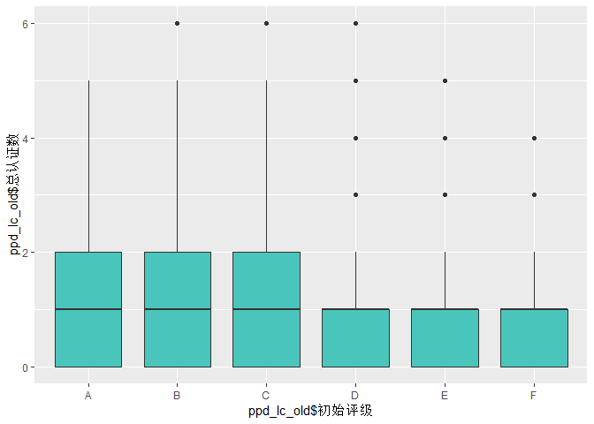

#### 初始评级 vs. 历史待还金额占整体债务比例： 评级越高，新接入资金占总体债务比例越低

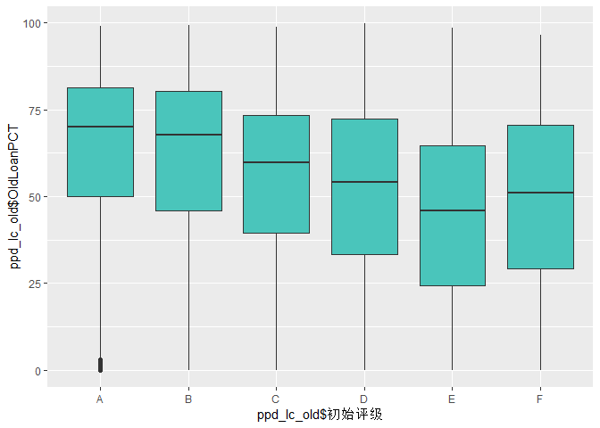

#### 初始评级 vs. 偿还率：评级较低的反而偿还率高，总体差距不大

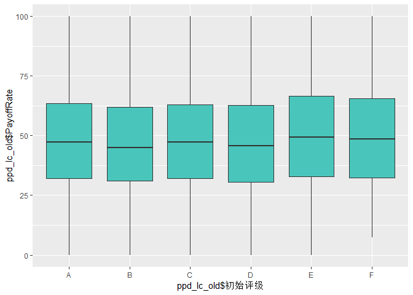

#### 初始评级 vs. 逾期率：评级低的逾期率高

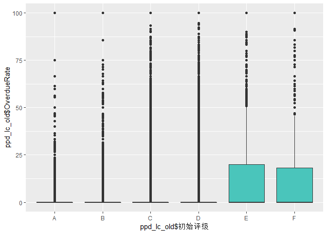